# R Notebook

Estrutura do artigo a ser escrito ao final do curso de machine leaning:

Abstract

Introdução - Vender o artigo (motivar, falar sobre a relevância, convencer) - Sintética ou Autocontida - Sintética é aquela pequena que vai direto ao ponto e normalente tem 2 a 3 páginas. - Autocontida é aquela mais longa que normalmente tem mais de 5 páginas. Fala um pouco de tudo que contém no artigo.

Revisão bibliográfica - 1 parágrafo, 1 tópico e ao fim, um “fecho”.

Dados - descrever sua base de dados; - descrição, método de coleta; - análise exploratória de dados (mostrar os dados para o leitor atraves de tabelas, gráficos, mapas, prints, etc);

Metodologia - qual o paradigma você está utilizando (supervisionado, nmão supervisionado e semi-supervisionado); - especificar o algoritimo que será utilizado;

Resultados - Discussão - Mostrar resultados das performances dos diferentes algoritimos;

Conclusões

Referencias

Aqui começa um estudo sobre as aulas que do professor

```r
library(ggplot2)
library(data.table)
library(stargazer)
library(skimr)

credit = fread("data/German_credit_processed.csv")
head(credit)
```

| Customer_ID | checking_account_status | loan_duration_mo | credit_history | purpose | loan_amount | savings_account_balance | time_employed_yrs | payment_pcnt_income | gender_status | other_signators | time_in_residence | property | age_yrs | other_credit_outstanding | home_ownership | number_loans | job_category | dependents | telephone | foreign_worker | bad_credit |
| --- | --- | --- | --- | --- | --- | --- | --- | --- | --- | --- | --- | --- | --- | --- | --- | --- | --- | --- | --- | --- | --- |
| 1122334 | < 0 DM | 6 | critical account - other non-bank loans | radio/television | 1169 | unknown/none | >= 7 years | 4 | male-single | none | 4 | real estate | 67 | none | own | 2 | skilled | 1 | yes | yes | 0 |
| 6156361 | 0 - 200 DM | 48 | current loans paid | radio/television | 5951 | < 100 DM | 1 - 4 years | 2 | female-divorced/separated/married | none | 2 | real estate | 22 | none | own | 1 | skilled | 1 | none | yes | 1 |
| 2051359 | none | 12 | critical account - other non-bank loans | education | 2096 | < 100 DM | 4 - 7 years | 2 | male-single | none | 3 | real estate | 49 | none | own | 1 | unskilled-resident | 2 | none | yes | 0 |
| 8740590 | < 0 DM | 42 | current loans paid | furniture/equipment | 7882 | < 100 DM | 4 - 7 years | 2 | male-single | guarantor | 4 | building society savings/life insurance | 45 | none | for free | 1 | skilled | 2 | none | yes | 0 |
| 3924540 | < 0 DM | 24 | past payment delays | car (new) | 4870 | < 100 DM | 1 - 4 years | 3 | male-single | none | 4 | unknown-none | 53 | none | for free | 2 | skilled | 2 | none | yes | 1 |
| 3115687 | none | 36 | current loans paid | education | 9055 | unknown/none | 1 - 4 years | 2 | male-single | none | 4 | unknown-none | 35 | none | for free | 1 | unskilled-resident | 2 | yes | yes | 0 |

```r
str(credit)
```

```
## Classes 'data.table' and 'data.frame':   1012 obs. of  22 variables:
##  $ Customer_ID             : int  1122334 6156361 2051359 8740590 3924540 3115687 8251714 2272783 1865292 8369450 ...
##  $ checking_account_status : chr  "< 0 DM" "0 - 200 DM" "none" "< 0 DM" ...
##  $ loan_duration_mo        : int  6 48 12 42 24 36 24 36 12 30 ...
##  $ credit_history          : chr  "critical account - other non-bank loans" "current loans paid" "critical account - other non-bank loans" "current loans paid" ...
##  $ purpose                 : chr  "radio/television" "radio/television" "education" "furniture/equipment" ...
##  $ loan_amount             : int  1169 5951 2096 7882 4870 9055 2835 6948 3059 5234 ...
##  $ savings_account_balance : chr  "unknown/none" "< 100 DM" "< 100 DM" "< 100 DM" ...
##  $ time_employed_yrs       : chr  ">= 7 years" "1 - 4 years" "4 - 7 years" "4 - 7 years" ...
##  $ payment_pcnt_income     : int  4 2 2 2 3 2 3 2 2 4 ...
##  $ gender_status           : chr  "male-single" "female-divorced/separated/married" "male-single" "male-single" ...
##  $ other_signators         : chr  "none" "none" "none" "guarantor" ...
##  $ time_in_residence       : int  4 2 3 4 4 4 4 2 4 2 ...
##  $ property                : chr  "real estate" "real estate" "real estate" "building society savings/life insurance" ...
##  $ age_yrs                 : int  67 22 49 45 53 35 53 35 61 28 ...
##  $ other_credit_outstanding: chr  "none" "none" "none" "none" ...
##  $ home_ownership          : chr  "own" "own" "own" "for free" ...
##  $ number_loans            : int  2 1 1 1 2 1 1 1 1 2 ...
##  $ job_category            : chr  "skilled" "skilled" "unskilled-resident" "skilled" ...
##  $ dependents              : int  1 1 2 2 2 2 1 1 1 1 ...
##  $ telephone               : chr  "yes" "none" "none" "none" ...
##  $ foreign_worker          : chr  "yes" "yes" "yes" "yes" ...
##  $ bad_credit              : int  0 1 0 0 1 0 0 0 0 1 ...
##  - attr(*, ".internal.selfref")=<externalptr>
```

```r
stargazer(credit, type = "text")
```

```
##
## =================================================================================================
## Statistic             N       Mean        St. Dev.       Min     Pctl(25)    Pctl(75)      Max
## -------------------------------------------------------------------------------------------------
## Customer_ID         1,012 5,414,623.000 2,569,715.000 1,018,706 3,209,457.0 7,533,738.0 9,994,482
## loan_duration_mo    1,012    20.854        12.031         4         12          24         72
## loan_amount         1,012   3,265.124     2,817.639      250       1,364      3,972.2    18,424
## payment_pcnt_income 1,012     2.970         1.119         1          2           4          4
## time_in_residence   1,012     2.843         1.106         1          2           4          4
## age_yrs             1,012    35.584        11.394        19         27          42         75
## number_loans        1,012     1.407         0.580         1          1           2          4
## dependents          1,012     1.155         0.362         1          1           1          2
## bad_credit          1,012     0.298         0.458         0          0           1          1
## -------------------------------------------------------------------------------------------------
```

```r
skim(credit) %>% kable()
```

```
## Skim summary statistics
##  n obs: 1012
##  n variables: 22
##
## Variable type: character
##
##          variable            missing    complete     n      min    max    empty    n_unique
## --------------------------  ---------  ----------  ------  -----  -----  -------  ----------
##  checking_account_status        0         1012      1012     4     29       0         4
##       credit_history            0         1012      1012    16     39       0         5
##       foreign_worker            0         1012      1012     2      3       0         2
##       gender_status             0         1012      1012    11     33       0         4
##       home_ownership            0         1012      1012     3      8       0         3
##        job_category             0         1012      1012     7     33       0         4
##  other_credit_outstanding       0         1012      1012     4      6       0         3
##      other_signators            0         1012      1012     4     12       0         3
##          property               0         1012      1012    11     39       0         4
##          purpose                0         1012      1012     5     19       0         10
##  savings_account_balance        0         1012      1012     8     13       0         5
##         telephone               0         1012      1012     3      4       0         2
##     time_employed_yrs           0         1012      1012     8     11       0         5
##
## Variable type: integer
##
##       variable          missing    complete     n         mean           sd         p0         p25          p50         p75        p100       hist
## ---------------------  ---------  ----------  ------  ------------  ------------  -------  ------------  ---------  ------------  -------  ----------
##        age_yrs             0         1012      1012      35.58         11.39        19          27          33           42         75      ▇▇▆▃▂▁▁▁
##      bad_credit            0         1012      1012       0.3           0.46         0          0            0           1           1      ▇▁▁▁▁▁▁▃
##      Customer_ID           0         1012      1012    5414622.72    2569714.99    1e+06    3209456.75    5477769    7533738.25    1e+07    ▇▇▇▇▇▇▇▆
##      dependents            0         1012      1012       1.16          0.36         1          1            1           1           2      ▇▁▁▁▁▁▁▂
##      loan_amount           0         1012      1012     3265.12       2817.64       250        1364        2309       3972.25      18424    ▇▃▂▁▁▁▁▁
##   loan_duration_mo         0         1012      1012      20.85         12.03         4          12          18           24         72      ▇▅▅▃▁▁▁▁
##     number_loans           0         1012      1012       1.41          0.58         1          1            1           2           4      ▇▁▅▁▁▁▁▁
##  payment_pcnt_income       0         1012      1012       2.97          1.12         1          2            3           4           4      ▂▁▃▁▁▂▁▇
##   time_in_residence        0         1012      1012       2.84          1.11         1          2            3           4           4      ▂▁▆▁▁▃▁▇
```

```r
credit$bad_credit = as.factor(credit$bad_credit)
table(credit$bad_credit)
```

```
##
##   0   1
## 710 302
```

Criação de boxplots

Um box plot

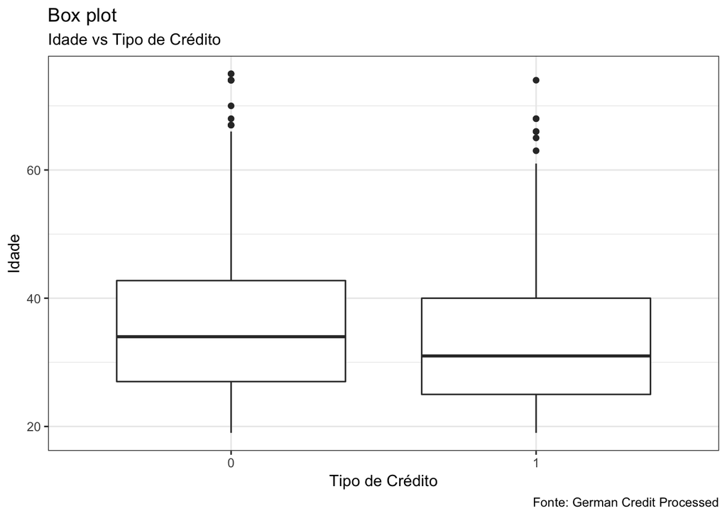

```r
#Utilizando somente uma variável
ggplot(data = credit, aes(bad_credit, age_yrs)) +
  geom_boxplot() +
  labs(title = "Box plot",
         subtitle = "Idade vs Tipo de Crédito",
         caption = "Fonte: German Credit Processed",
         x = "Tipo de Crédito",
         y = "Idade") +
  theme_bw()
```

Vários box plots (com várias variáveis do banco de dados)

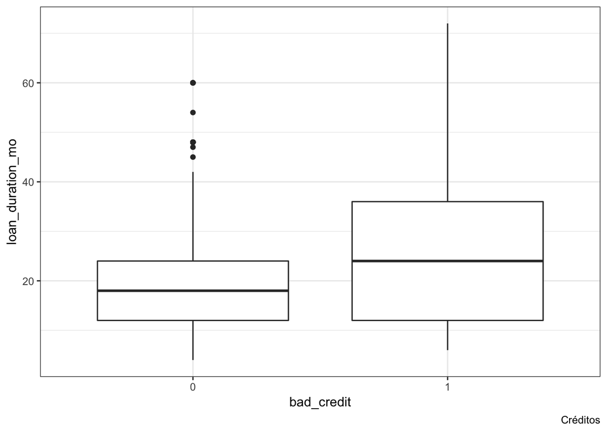

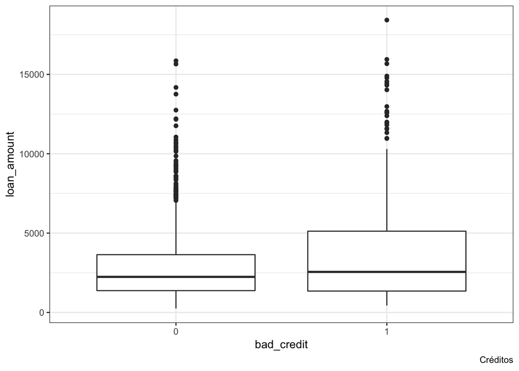

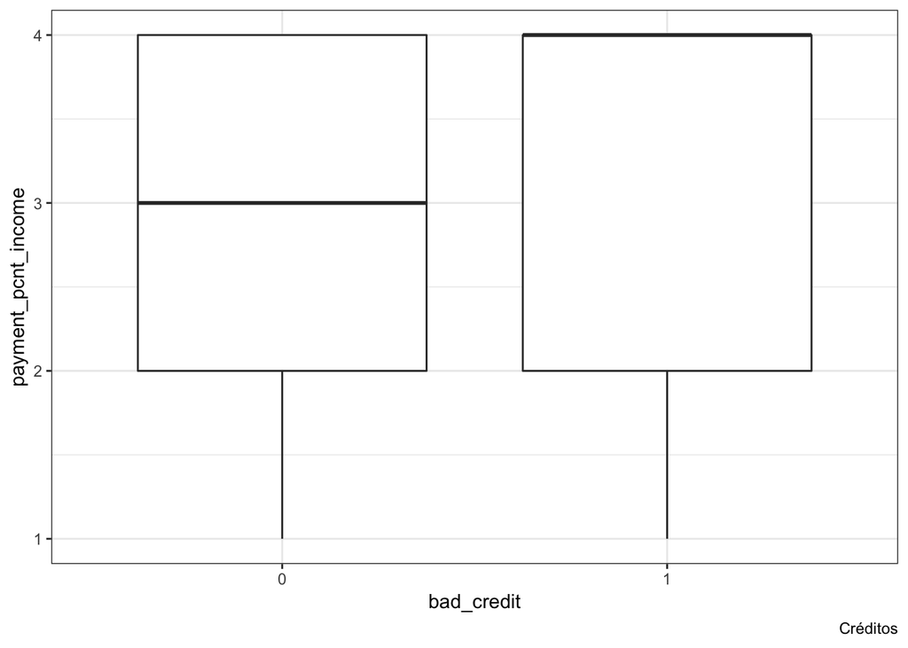

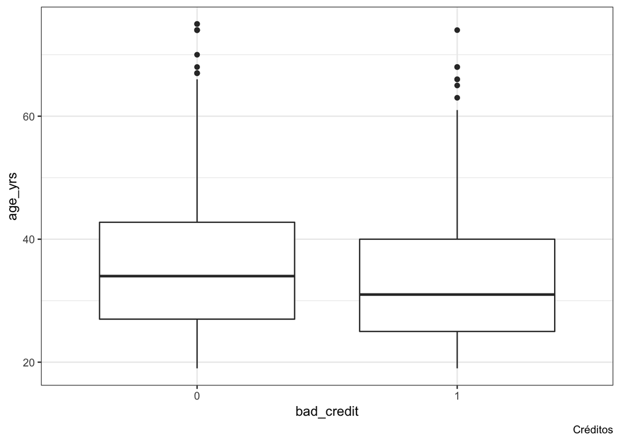

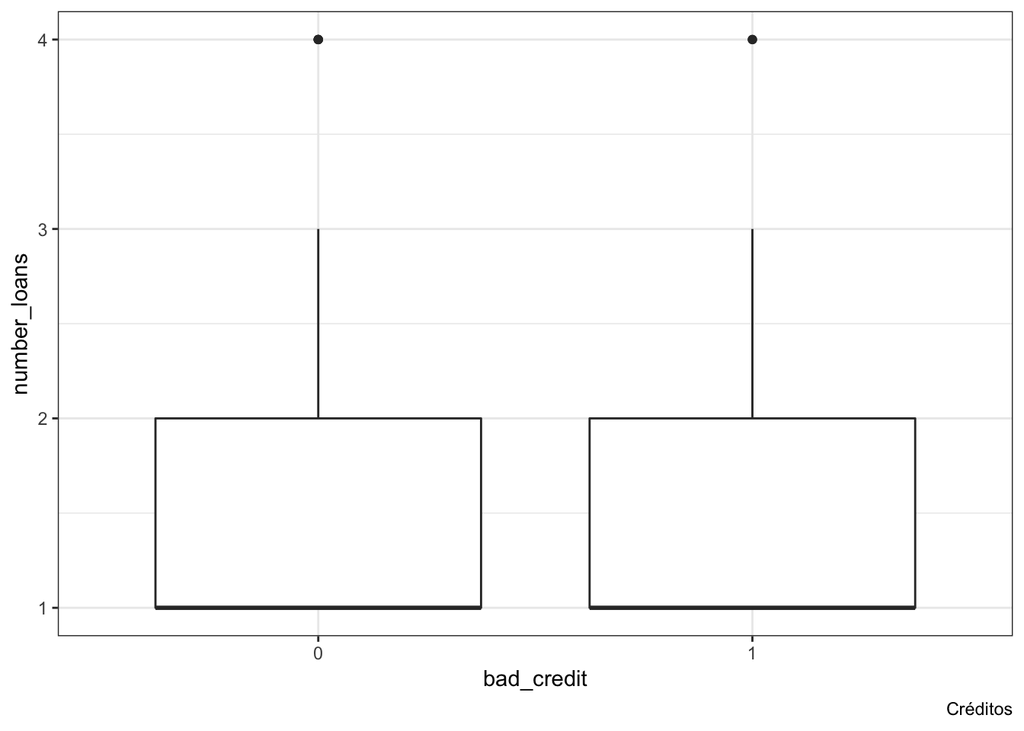

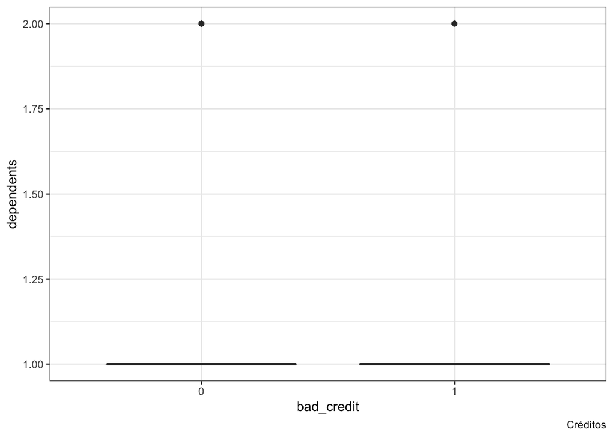

```r
# Função para criação de um boxplot
box_plot = function(data, atributos, variavelDependente = 'bad_credit'){
  for (atributo in atributos) {
    result = ggplot(data = data, aes_string(variavelDependente, atributo)) +
              geom_boxplot() +
              labs(x = variavelDependente,
                   y = atributo,
                   caption = "Créditos") +
              theme_bw()
    print(result)
  }
}

box_plot(credit, c('loan_duration_mo', 'loan_amount',
                         'payment_pcnt_income', 'age_yrs',
                         'number_loans', 'dependents'))
```

Criação de violins (grafico)

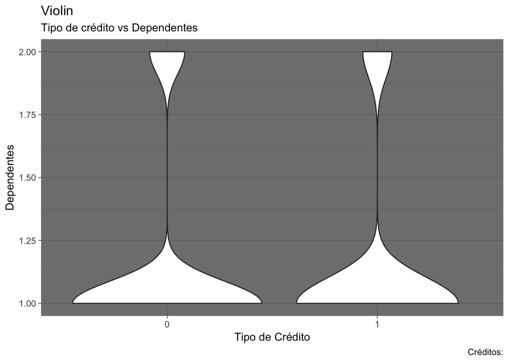

```r
ggplot(credit, aes(bad_credit, dependents)) +
  geom_violin() +
  labs(title = "Violin",
       subtitle = "Tipo de crédito vs Dependentes",
       x = "Tipo de Crédito",
       y = "Dependentes",
       caption = "Créditos:") +
  theme_dark()
```

Vários graficos de Violin (com várias variáveis do banco de dados)

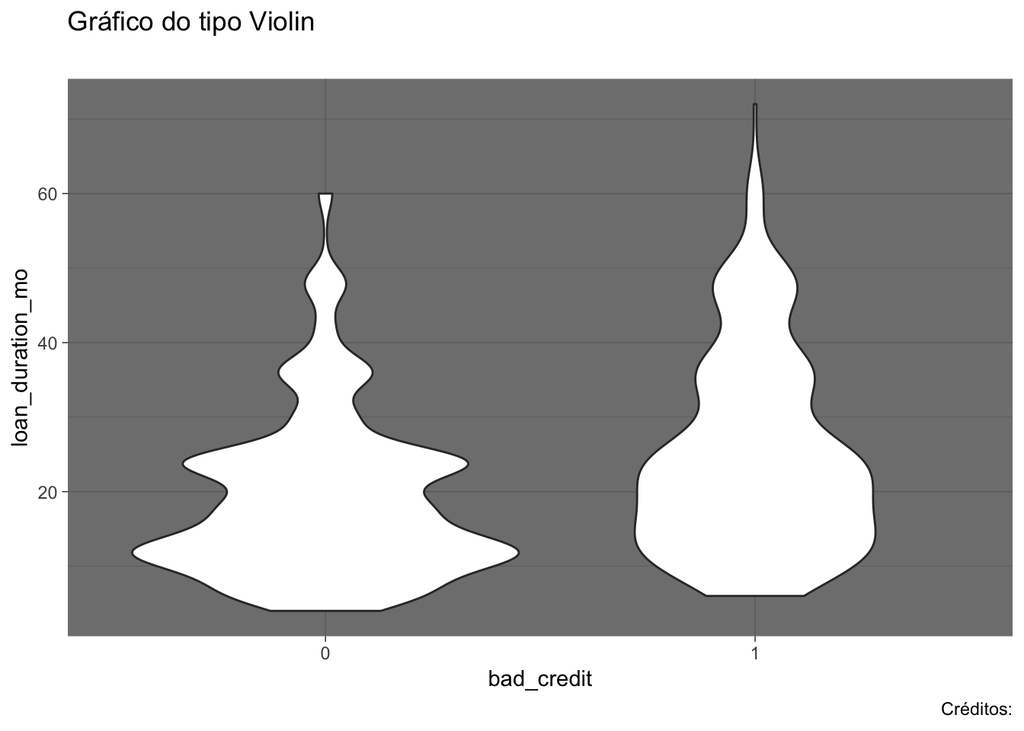

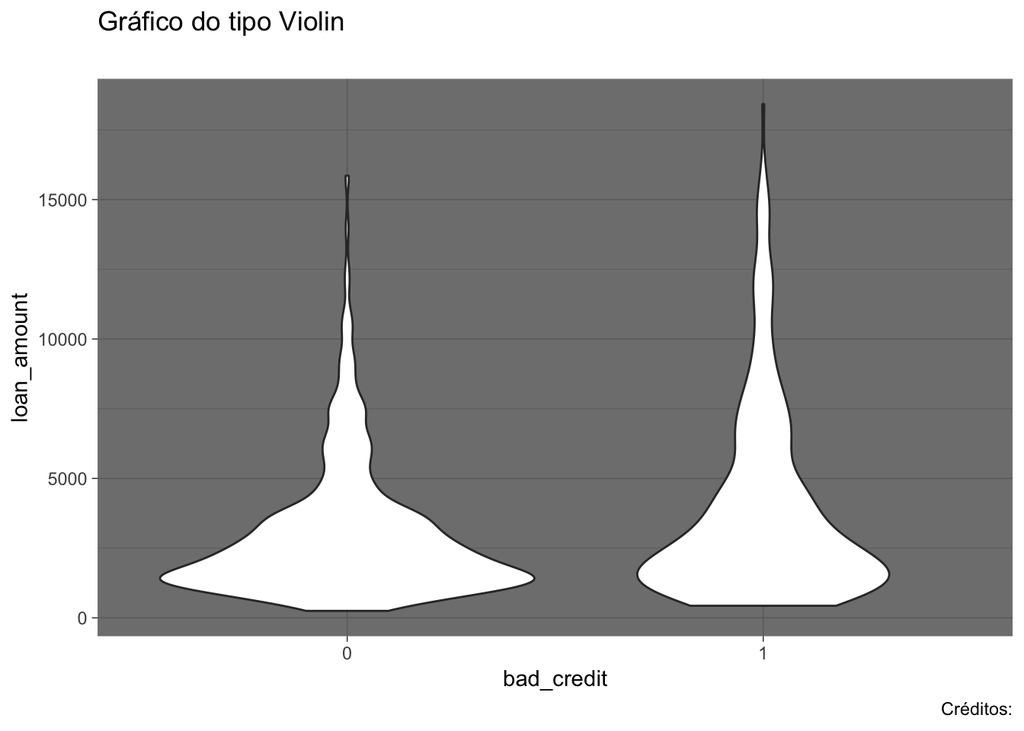

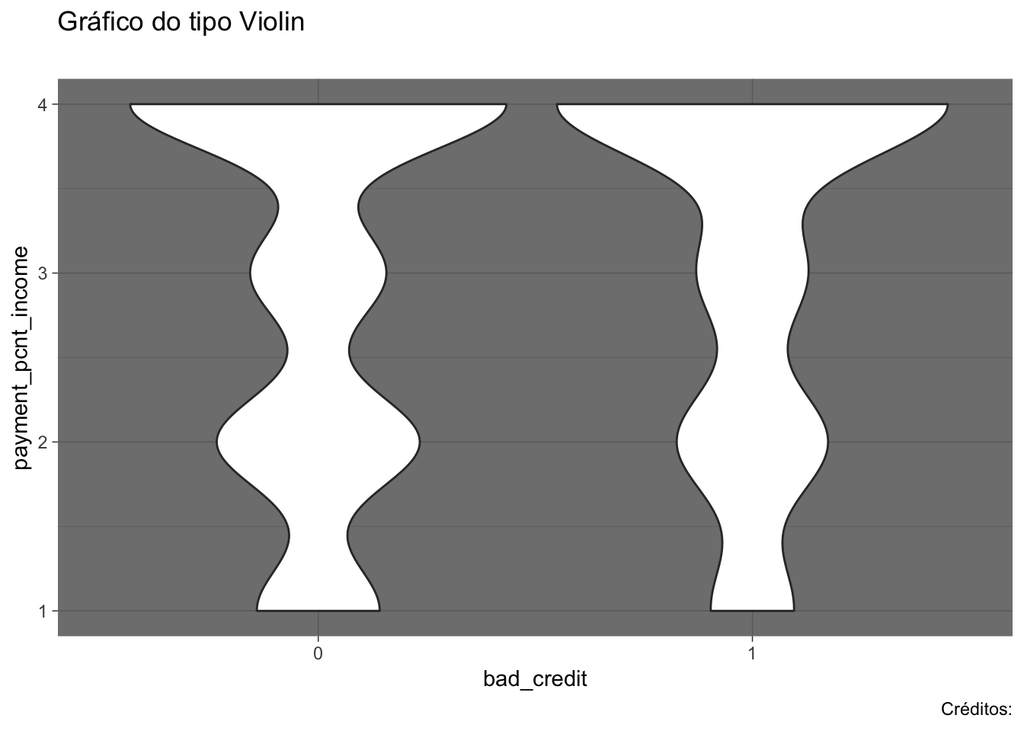

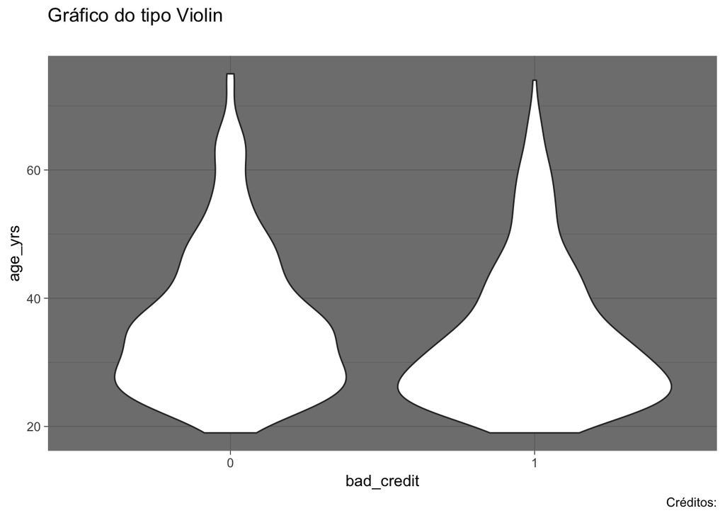

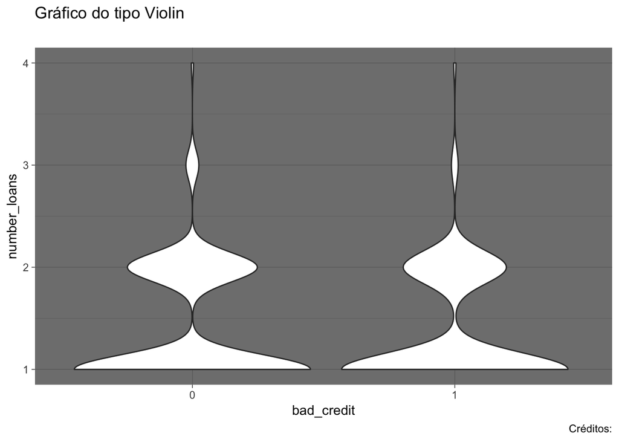

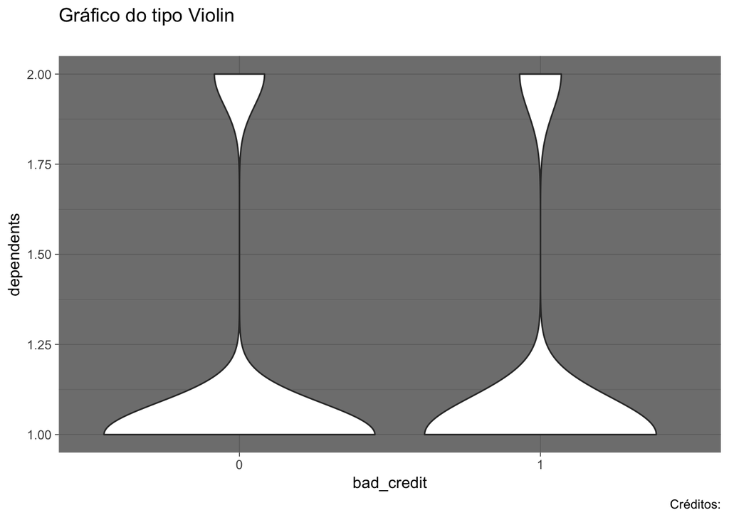

```r
violin_plot = function(data, atributos, atributoDependente = 'bad_credit'){
  for (atributo in atributos) {
    result = ggplot(data = data, aes_string(atributoDependente, atributo)) +
              geom_violin() +
              theme_dark() +
              labs(title = "Gráfico do tipo Violin",
                   subtitle = "",
                   x = atributoDependente,
                   y = atributo,
                   caption = "Créditos:")

    print(result)
  }
}

violin_plot(credit, c('loan_duration_mo', 'loan_amount',
                         'payment_pcnt_income', 'age_yrs',
                         'number_loans', 'dependents'))
```